# Data Catalog Pipeline and Design

Justin Singh-Mohudpur

2023-07-13

# Overview

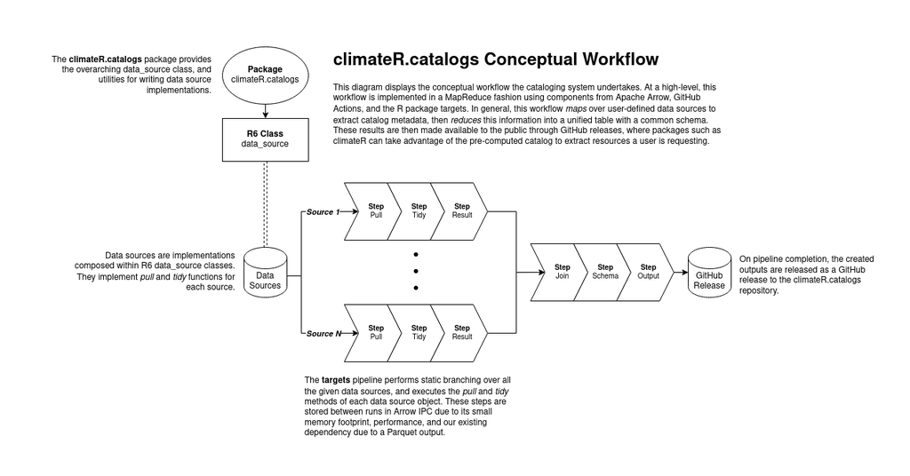

# Data Source

Data sources in `climateR.catalogs` are defined by a singular [R6 Class](https://r6.r-lib.org/articles/Introduction.html), `climateR.catalogs::data_source`. This R6 class provides the back-end plumbing for pulling, tidying, and IPC.

## Example Implementation

Data sources are created by defining 3 things:

1. An identifier unique to the data source,
2. A `pull` function,
3. A `tidy` function.

For example, let’s reimplement the [GRIDMET](https://www.climatologylab.org/gridmet.html) data source.

### Pull

The GRIDMET dataset is accessible via OPeNDAP from associated THREDDS server. Using this THREDDS Data Server, we can use some convenience functions to read from it:

```r
arrow::as_arrow_table(climateR.catalogs::read_tds(
    paste0(
        "http://thredds.northwestknowledge.net:8080",
        "/thredds/reacch_climate_MET_aggregated_catalog.html"
    ),
    "gridmet"
))
```

```
#> Table
#> 42 rows x 3 columns
#> $link <string>
#> $id <string>
#> $URL <string>
```

One thing you may notice is that we are converting the output of `read_tds` to an Arrow Table. We do this for a few reasons:

- The `targets` pipeline saves/loads previous targets through Arrow IPC.
- The `data_source` R6 objects are easily defined in Arrow IPC by taking advantage of metadata within the schema.
- We can take advantage of Arrow compute capabilities where applicable, so it makes sense to convert as early as possible.

Now that we have this table, we can wrap a function around it, and assign it as our pull function for the data source:

```r
.pull_gridmet <- function(...) {
    arrow::as_arrow_table(climateR.catalogs::read_tds(
        paste0(
            "http://thredds.northwestknowledge.net:8080",
            "/thredds/reacch_climate_MET_aggregated_catalog.html"
        ),
        "gridmet"
    ))
}
```

### Tidy

With our pull function implemented, the next step is to read in the actual catalog information, and align it to the catalog schema. This implementation is housed within the data source’s `tidy` function. Like the pull function, the tidy function should output an Arrow Table. It also should ensure as much of the catalog schema is available on output. Moreover, the tidy function has one extra requirement: it must have **at least 1 named parameter** that represents the output from the pull function.

Here is the implementation for our tidy function:

```r
.tidy_gridmet <- function(.tbl, ...) {
    dplyr::collect(.tbl) |>
    dplyr::rowwise() |>
    dplyr::group_map(~ tryCatch({
        climateR::read_dap_file(
            URL     = .x$URL[1],
            id      = .x$variable[1],
            varmeta = TRUE
        )}, error = function(condition) NULL)
    ) |>
    dplyr::bind_rows() |>
    arrow::as_arrow_table() |>
    dplyr::rename(variable = id) |>
    dplyr::left_join(dplyr::select(.tbl, -URL), by = "variable") |>
    dplyr::mutate(tiled = "", type = "opendap") |>
    dplyr::compute()
}
```

### Bringing It Together

With our `pull` and `tidy` functions defined, we can now create the data source object. Data sources are defined by a single file named like `ds-<name>.R` that contains *at least* the data source object. Any additional functions or symbols must have names prefixed with a `.`.

> The requirement for private symbols is due to how symbol names are read in during the initialization of the pipeline.

This file is create within the `sources/` directory. So, our GRIDMET file will be `sources/ds-gridmet.R`, and the contents will be:

```r
# sources/ds-gridmet.R

.pull_gridmet <- function(...)       { ... } # implementation as above
.tidy_gridmet <- function(.tbl, ...) { ... } # implementation as above

ds_gridmet <- climateR.catalogs::data_source$new(
    id   = "gridmet",
    pull = .pull_gridmet, # note: we are passing the function, not calling it
    tidy = .tidy_gridmet
)
```

> *Note*: The name of actual R6 object has no restrictions, but typically it will follow a similar pattern of `ds_<name>`. This is the name the `targets` pipeline will use for its derived targets.

With this file implemented, we now have all the necessary components for our pipeline to recognize and run with the new catalog data source! The pipeline itself is designed with a *plugin architecture* in mind, meaning that sources can be added and removed without modifying the pipeline itself, or the `climateR.catalogs` package.

# Pipeline

The data pipeline for `climateR.catalogs` uses targets. `targets` is a Make-like declarative workflow engine written for R in R. `targets` has the advantage of easy parallelization, and native support for remote resources.

[interactive chart not shown]